# Practical Machine Learning Project

Jianhua Huang

Tuesday, January 13, 2015

### Synopsis

This project is aimed at using various machine learning methods to explore the weight lifting exercise dataset. The goal is to predict the exercise classes based on a set of predictors. In this exercise, we mainly ask four questions:

1. How you built the model
2. How you used cross validation
3. What is the out of sample error
4. Why you made the choice on the final model

1. Data cleaning and feature selection
2. Building models
3. Model evaluation and test
4. Predicting results
5. Submitting results

### Data cleaning and feature selection

In this part, we first set up the R working options with the following commands.

```r
library(knitr)
opts_chunk$set(echo = T, message = FALSE, warning=FALSE,results ='markup', cache = F)
dir <- '/NAS/jhuang/Projects/PracticalMachineLearning'
opts_knit$set(root.dir = dir)
```

Then we load the original data into R with NA and “” set as missing values, and first column set as row names.

```r
invisible(sapply(c('caret', 'rattle', 'ggplot2', 'doMC'), require, character.only = T))
buildData <- read.csv('pml-training.csv', row.names = 1, na.string = c(NA, ''))
validation <- read.csv('pml-testing.csv', row.names = 1, na.string = c(NA, ''))
```

From the data, we can see a lot of missing data in some column, which we want to remove. In this research, I exclude all the columns with more than 90% of the values are missing data.

```r
naCol <- which(colSums(is.na(buildData)) > .9 * nrow(buildData))
buildData <- buildData[, -naCol]
validation <- validation[, -naCol]  # keep the same columns in validataion
```

After removing the missing data column, we can check whether there is any zero variance column with the `nearZeroVar` function:

```r
nzv <- nearZeroVar(buildData, saveMetrics = T)
nzv
```

```
##                      freqRatio percentUnique zeroVar   nzv
## user_name                1.101       0.03058   FALSE FALSE
## raw_timestamp_part_1     1.000       4.26562   FALSE FALSE
## raw_timestamp_part_2     1.000      85.53155   FALSE FALSE
## cvtd_timestamp           1.001       0.10193   FALSE FALSE
## new_window              47.330       0.01019   FALSE  TRUE
## num_window               1.000       4.37264   FALSE FALSE
## roll_belt                1.102       6.77811   FALSE FALSE
## pitch_belt               1.036       9.37723   FALSE FALSE
## yaw_belt                 1.058       9.97350   FALSE FALSE
## total_accel_belt         1.063       0.14779   FALSE FALSE
## gyros_belt_x             1.059       0.71348   FALSE FALSE
## gyros_belt_y             1.144       0.35165   FALSE FALSE
## gyros_belt_z             1.066       0.86128   FALSE FALSE
## accel_belt_x             1.055       0.83580   FALSE FALSE
## accel_belt_y             1.114       0.72877   FALSE FALSE
## accel_belt_z             1.079       1.52380   FALSE FALSE
## magnet_belt_x            1.090       1.66650   FALSE FALSE
## magnet_belt_y            1.100       1.51870   FALSE FALSE
## magnet_belt_z            1.006       2.32902   FALSE FALSE
## roll_arm                52.338      13.52563   FALSE FALSE
## pitch_arm               87.256      15.73234   FALSE FALSE
## yaw_arm                 33.029      14.65702   FALSE FALSE
## total_accel_arm          1.025       0.33636   FALSE FALSE
## gyros_arm_x              1.016       3.27693   FALSE FALSE
## gyros_arm_y              1.454       1.91622   FALSE FALSE
## gyros_arm_z              1.111       1.26389   FALSE FALSE
## accel_arm_x              1.017       3.95984   FALSE FALSE
## accel_arm_y              1.140       2.73672   FALSE FALSE
## accel_arm_z              1.128       4.03629   FALSE FALSE
## magnet_arm_x             1.000       6.82397   FALSE FALSE
## magnet_arm_y             1.057       4.44399   FALSE FALSE
## magnet_arm_z             1.036       6.44685   FALSE FALSE
## roll_dumbbell            1.022      83.78351   FALSE FALSE
## pitch_dumbbell           2.277      81.22516   FALSE FALSE
## yaw_dumbbell             1.132      83.14137   FALSE FALSE
## total_accel_dumbbell     1.073       0.21914   FALSE FALSE
## gyros_dumbbell_x         1.003       1.22821   FALSE FALSE
## gyros_dumbbell_y         1.265       1.41678   FALSE FALSE
## gyros_dumbbell_z         1.060       1.04984   FALSE FALSE
## accel_dumbbell_x         1.018       2.16594   FALSE FALSE
## accel_dumbbell_y         1.053       2.37489   FALSE FALSE
## accel_dumbbell_z         1.133       2.08949   FALSE FALSE
## magnet_dumbbell_x        1.098       5.74865   FALSE FALSE
## magnet_dumbbell_y        1.198       4.30129   FALSE FALSE
## magnet_dumbbell_z        1.021       3.44511   FALSE FALSE
## roll_forearm            11.589      11.08959   FALSE FALSE
## pitch_forearm           65.983      14.85577   FALSE FALSE
## yaw_forearm             15.323      10.14677   FALSE FALSE
## total_accel_forearm      1.129       0.35674   FALSE FALSE
## gyros_forearm_x          1.059       1.51870   FALSE FALSE
## gyros_forearm_y          1.037       3.77637   FALSE FALSE
## gyros_forearm_z          1.123       1.56457   FALSE FALSE
## accel_forearm_x          1.126       4.04648   FALSE FALSE
## accel_forearm_y          1.059       5.11161   FALSE FALSE
## accel_forearm_z          1.006       2.95587   FALSE FALSE
## magnet_forearm_x         1.012       7.76679   FALSE FALSE
## magnet_forearm_y         1.247       9.54031   FALSE FALSE
## magnet_forearm_z         1.000       8.57711   FALSE FALSE
## classe                   1.470       0.02548   FALSE FALSE
```

From the output, we can see that no column is zero variance. Thus, we want to keep all left columns in the following analysis.

In order to train and test the models, we need to first seperate the buildData into two parts: training data and testing data:

```r
inTrain <- createDataPartition(y = buildData$classe, p = .7, list = F)
training <- buildData[inTrain, ]
testing <- buildData[-inTrain, ]
```

We can check the dimension of the three datasets, to make sure they are cleaned up and split correctly.

```r
dim(training)
```

```
## [1] 13737    59
```

```r
dim(testing)
```

```
## [1] 5885   59
```

```r
dim(validation)
```

```
## [1] 20 59
```

### Building Models

```r
set.seed(123)
modLda <- train(classe ~ ., data = training, method = 'lda')

modRpart <- train(classe ~ ., data = training, method = 'rpart')

registerDoMC(cores = 12)
modGbm <- train(classe ~ ., data = training, method = 'gbm', verbose = F,
  trControl = trainControl(## 10-fold CV, repeat 3 times
    method = "repeatedcv", number = 4, repeats = 3))

registerDoMC(cores = 12)
modRf <- train(classe ~ ., data = training, method = 'rf',
  trControl = trainControl(method = 'cv', number = 10))
```

### Model evaluation and testing

When all models finish running, we can test their performance with the testing dataset. Because the testing data was not used to train the model, we expect that the out of sample errors from the testing dataset will be larger than the training dataset. Thus the accuracy of the testing dataset will be slightly lower than the training data. Here is the confusion matrix with the accuracy information for each training methods:

```r
print(confusionMatrix(predict(modLda, newdata = testing), testing$classe), digits = 3)
```

```
## Confusion Matrix and Statistics
##
##           Reference
## Prediction    A    B    C    D    E
##          A 1534  151    4    0    0
##          B  121  826  106    3    0
##          C   19  153  884  114    6
##          D    0    9   28  803   99
##          E    0    0    4   44  977
##
## Overall Statistics
##
##                Accuracy : 0.854
##                  95% CI : (0.844, 0.863)
##     No Information Rate : 0.284
##     P-Value [Acc > NIR] : <2e-16
##
##                   Kappa : 0.815
##  Mcnemar's Test P-Value : NA
##
## Statistics by Class:
##
##                      Class: A Class: B Class: C Class: D Class: E
## Sensitivity             0.916    0.725    0.862    0.833    0.903
## Specificity             0.963    0.952    0.940    0.972    0.990
## Pos Pred Value          0.908    0.782    0.752    0.855    0.953
## Neg Pred Value          0.967    0.935    0.970    0.967    0.978
## Prevalence              0.284    0.194    0.174    0.164    0.184
## Detection Rate          0.261    0.140    0.150    0.136    0.166
## Detection Prevalence    0.287    0.179    0.200    0.160    0.174
## Balanced Accuracy       0.940    0.838    0.901    0.903    0.946
```

```r
print(confusionMatrix(predict(modRpart, newdata = testing), testing$classe), digits = 3)
```

```
## Confusion Matrix and Statistics
##
##           Reference
## Prediction    A    B    C    D    E
##          A 1543  596  171  311   81
##          B   17  314   55  144  303
##          C  111  229  800  509  217
##          D    0    0    0    0    0
##          E    3    0    0    0  481
##
## Overall Statistics
##
##                Accuracy : 0.533
##                  95% CI : (0.52, 0.546)
##     No Information Rate : 0.284
##     P-Value [Acc > NIR] : <2e-16
##
##                   Kappa : 0.395
##  Mcnemar's Test P-Value : NA
##
## Statistics by Class:
##
##                      Class: A Class: B Class: C Class: D Class: E
## Sensitivity             0.922   0.2757    0.780    0.000   0.4445
## Specificity             0.725   0.8906    0.781    1.000   0.9994
## Pos Pred Value          0.571   0.3770    0.429      NaN   0.9938
## Neg Pred Value          0.959   0.8367    0.944    0.836   0.8887
## Prevalence              0.284   0.1935    0.174    0.164   0.1839
## Detection Rate          0.262   0.0534    0.136    0.000   0.0817
## Detection Prevalence    0.459   0.1415    0.317    0.000   0.0822
## Balanced Accuracy       0.823   0.5832    0.780    0.500   0.7220
```

```r
print(confusionMatrix(predict(modGbm, newdata = testing), testing$classe), digits = 3)
```

```
## Confusion Matrix and Statistics
##
##           Reference
## Prediction    A    B    C    D    E
##          A 1674    2    0    0    0
##          B    0 1133    2    0    0
##          C    0    2 1012    1    0
##          D    0    2   12  962    0
##          E    0    0    0    1 1082
##
## Overall Statistics
##
##                Accuracy : 0.996
##                  95% CI : (0.994, 0.998)
##     No Information Rate : 0.284
##     P-Value [Acc > NIR] : <2e-16
##
##                   Kappa : 0.995
##  Mcnemar's Test P-Value : NA
##
## Statistics by Class:
##
##                      Class: A Class: B Class: C Class: D Class: E
## Sensitivity             1.000    0.995    0.986    0.998    1.000
## Specificity             1.000    1.000    0.999    0.997    1.000
## Pos Pred Value          0.999    0.998    0.997    0.986    0.999
## Neg Pred Value          1.000    0.999    0.997    1.000    1.000
## Prevalence              0.284    0.194    0.174    0.164    0.184
## Detection Rate          0.284    0.193    0.172    0.163    0.184
## Detection Prevalence    0.285    0.193    0.172    0.166    0.184
## Balanced Accuracy       1.000    0.997    0.993    0.998    1.000
```

```r
print(confusionMatrix(predict(modRf, newdata = testing), testing$classe), digits = 3)
```

```
## Confusion Matrix and Statistics
##
##           Reference
## Prediction    A    B    C    D    E
##          A 1674    0    0    0    0
##          B    0 1139    1    0    0
##          C    0    0 1024    0    0
##          D    0    0    1  963    0
##          E    0    0    0    1 1082
##
## Overall Statistics
##
##                Accuracy : 0.999
##                  95% CI : (0.999, 1)
##     No Information Rate : 0.284
##     P-Value [Acc > NIR] : <2e-16
##
##                   Kappa : 0.999
##  Mcnemar's Test P-Value : NA
##
## Statistics by Class:
##
##                      Class: A Class: B Class: C Class: D Class: E
## Sensitivity             1.000    1.000    0.998    0.999    1.000
## Specificity             1.000    1.000    1.000    1.000    1.000
## Pos Pred Value          1.000    0.999    1.000    0.999    0.999
## Neg Pred Value          1.000    1.000    1.000    1.000    1.000
## Prevalence              0.284    0.194    0.174    0.164    0.184
## Detection Rate          0.284    0.194    0.174    0.164    0.184
## Detection Prevalence    0.284    0.194    0.174    0.164    0.184
## Balanced Accuracy       1.000    1.000    0.999    0.999    1.000
```

From these results, we can see that the random forest and gradient boosting models perform best with accuracy very close 1, followed by decent accuracy in linear discriminant analysis. But the decision tree model doesn’t work well, with accuracy being about 0.5.

### Predicting results

With the above models, we can predict the results for validation data.

```r
predict(modLda, validation)
```

```
##  [1] B B B A A E D C A A B C B A E E A B B B
## Levels: A B C D E
```

```r
predict(modRpart, validation)
```

```
##  [1] A A C A A C C C A A C C B A C B B A A B
## Levels: A B C D E
```

```r
predict(modGbm, validation)
```

```
##  [1] B A B A A E D B A A B C B A E E A B B B
## Levels: A B C D E
```

```r
predict(modRf, validation)
```

```
##  [1] B A B A A E D B A A B C B A E E A B B B
## Levels: A B C D E
```

We can see that, the results from random forest model and gradient boosting model are exactly the same. We can plot the decision tree flowchart and the clustering figures to check the results:

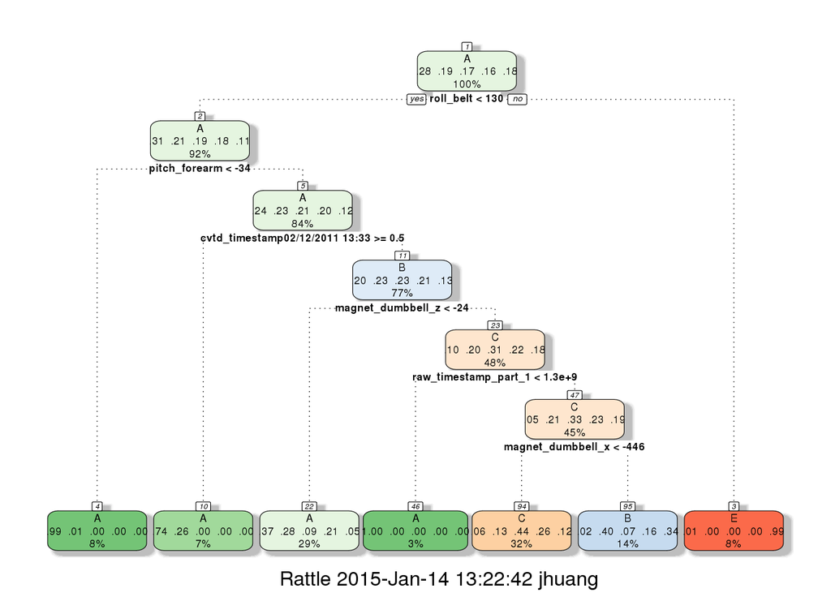

```r
fancyRpartPlot(modRpart$finalModel)
```

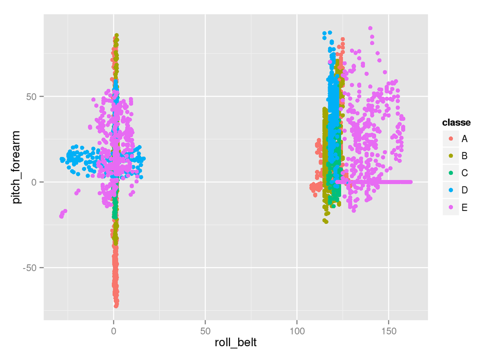

```r
qplot(roll_belt, pitch_forearm, colour = classe, data = testing)
```

### Submitting results

We finally choose the results from random forest model, because its accuracy is highese to submit to the course project.

Firstly, we prepare the results with the following codes:

```r
answers <- predict(modRf, newdata = validation)

pml_write_files = function(x){
  n = length(x)
  for(i in 1:n){
    filename = paste0("PML.project/problem_id_",i,".txt")
    write.table(x[i],file=filename,quote=FALSE,row.names=FALSE,col.names=FALSE)
  }
}

pml_write_files(answers)
```

Then, we can submit the file to the corresponding questions!